# Assignment3

Saloni Bhatia

May 27, 2019

### Q1: GitHub Cloning (20 points): Using Git, clone the following GitHub repository to your local machine: [https://github.com/caesar0301/awesome-public-datasets]

Solution:Cloned to “C:/SMU/DoingDataScience/Unit3/awesome-public-datasets**

### Q2- Data Summary (20 points): From this aforementioned cloned repo, please extract titanic.csv.zip. To be clear, this does not have to be done in Git or command line.

#### A - In R, please read in titanic.csv via either read.table() or read.csv(), assigning it to df. This dataset follows the passengers aboard the Titanic, including their fees paid, rooms rented, and survivorship status.

Solution: Read File from the cloned path

```r
df <- read.csv("C:/SMU/DoingDataScience/Unit3/awesome-public-datasets/Datasets/titanic.csv")

str(df)
```

```
## 'data.frame':    891 obs. of  12 variables:
##  $ PassengerId: int  1 2 3 4 5 6 7 8 9 10 ...
##  $ Survived   : int  0 1 1 1 0 0 0 0 1 1 ...
##  $ Pclass     : int  3 1 3 1 3 3 1 3 3 2 ...
##  $ Name       : Factor w/ 891 levels "Abbing, Mr. Anthony",..: 109 191 358 277 16 559 520 629 417 581 ...
##  $ Sex        : Factor w/ 2 levels "female","male": 2 1 1 1 2 2 2 2 1 1 ...
##  $ Age        : num  22 38 26 35 35 NA 54 2 27 14 ...
##  $ SibSp      : int  1 1 0 1 0 0 0 3 0 1 ...
##  $ Parch      : int  0 0 0 0 0 0 0 1 2 0 ...
##  $ Ticket     : Factor w/ 681 levels "110152","110413",..: 524 597 670 50 473 276 86 396 345 133 ...
##  $ Fare       : num  7.25 71.28 7.92 53.1 8.05 ...
##  $ Cabin      : Factor w/ 148 levels "","A10","A14",..: 1 83 1 57 1 1 131 1 1 1 ...
##  $ Embarked   : Factor w/ 4 levels "","C","Q","S": 4 2 4 4 4 3 4 4 4 2 ...
```

```r
summary(df)
```

```
##   PassengerId       Survived          Pclass
##  Min.   :  1.0   Min.   :0.0000   Min.   :1.000
##  1st Qu.:223.5   1st Qu.:0.0000   1st Qu.:2.000
##  Median :446.0   Median :0.0000   Median :3.000
##  Mean   :446.0   Mean   :0.3838   Mean   :2.309
##  3rd Qu.:668.5   3rd Qu.:1.0000   3rd Qu.:3.000
##  Max.   :891.0   Max.   :1.0000   Max.   :3.000
##
##                                     Name         Sex           Age
##  Abbing, Mr. Anthony                  :  1   female:314   Min.   : 0.42
##  Abbott, Mr. Rossmore Edward          :  1   male  :577   1st Qu.:20.12
##  Abbott, Mrs. Stanton (Rosa Hunt)     :  1                Median :28.00
##  Abelson, Mr. Samuel                  :  1                Mean   :29.70
##  Abelson, Mrs. Samuel (Hannah Wizosky):  1                3rd Qu.:38.00
##  Adahl, Mr. Mauritz Nils Martin       :  1                Max.   :80.00
##  (Other)                              :885                NA's   :177
##      SibSp           Parch             Ticket         Fare
##  Min.   :0.000   Min.   :0.0000   1601    :  7   Min.   :  0.00
##  1st Qu.:0.000   1st Qu.:0.0000   347082  :  7   1st Qu.:  7.91
##  Median :0.000   Median :0.0000   CA. 2343:  7   Median : 14.45
##  Mean   :0.523   Mean   :0.3816   3101295 :  6   Mean   : 32.20
##  3rd Qu.:1.000   3rd Qu.:0.0000   347088  :  6   3rd Qu.: 31.00
##  Max.   :8.000   Max.   :6.0000   CA 2144 :  6   Max.   :512.33
##                                   (Other) :852
##          Cabin     Embarked
##             :687    :  2
##  B96 B98    :  4   C:168
##  C23 C25 C27:  4   Q: 77
##  G6         :  4   S:644
##  C22 C26    :  3
##  D          :  3
##  (Other)    :186
```

#### B - Output the respective count of females and males aboard the Titanic. Plot the frequency of females and males. Be sure to give an accurate title and label the axes.

**Solution: Count of Females and Males. Plot the frequency.**

```r
TotalFemales <- as.data.frame(table(df$Sex))
#print(TotalFemales)
#summary(TotalFemales)
names(TotalFemales)[1] <- "Gender"
names(TotalFemales)[2] <- "TotalFrequency"
TotalFemales
```

```
##   Gender TotalFrequency
## 1 female            314
## 2   male            577
```

Plot

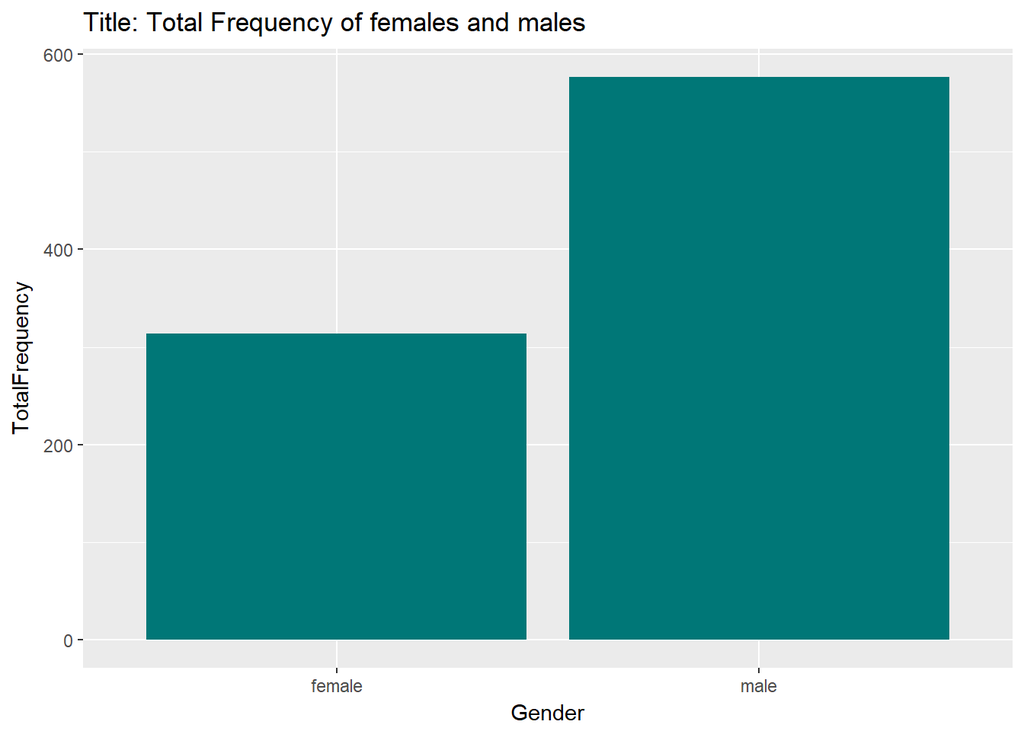

```r
library(ggplot2)
ggplot(TotalFemales, aes(x=Gender, y=TotalFrequency)) + geom_bar(fill="#007777FF", stat="identity") + ggtitle("Title: Total Frequency of females and males")
```

#### C - Please use one apply function (to review: swirl() modules 11, 12) to output the means of Age, Fare, and Survival. Make sure the output is a real number for all three means.

Solution: Calculate Means of Age, Fare, and Survival

```r
CalculateMean <- function(x)
              {
                summary <- summary(x)
                summary[4]
              }
vapply(df[,c("Age", "Fare", "Survived")], CalculateMean, numeric(1))
```

```
##      Age     Fare Survived
##  29.7000  32.2000   0.3838
```

### Q3 - Function Building (30 points): You research sleep and just got your first data set. Later, you’ll have another dataset with the same column names, so you want to create a helper function that you can analyze this dataset and the next. Load sleep_data_01.csv (found at http://talklab.psy.gla.ac.uk/L1_labs/lab_1/homework/index.html). Questions 3A through 3D should be answered in function(x){}. 3E can be outside of the function

Solution: Read sleep data file

```r
s <- read.csv("C:/SMU/DoingDataScience/Unit3/sleep_data_01.csv")

str(s)
```

```
## 'data.frame':    101 obs. of  15 variables:
##  $ SubjID  : int  1 2 3 4 5 6 7 8 9 10 ...
##  $ Age     : int  16 16 16 16 16 16 16 13 12 16 ...
##  $ Gender  : int  2 1 1 1 1 1 1 1 1 2 ...
##  $ PSQI    : int  5 4 7 6 8 15 7 4 5 4 ...
##  $ PSAScog : int  8 31 9 17 33 NA 27 13 14 11 ...
##  $ FOMO    : int  18 41 16 22 36 NA 15 17 25 16 ...
##  $ SMUISa  : int  19 25 17 14 NA NA 20 9 15 7 ...
##  $ SM1     : int  11 18 16 17 NA NA 21 17 17 13 ...
##  $ SM2     : int  12 21 14 13 NA NA 24 2 7 11 ...
##  $ HADSa   : int  10 20 7 9 NA NA 13 9 10 4 ...
##  $ HADSd   : int  8 8 3 5 NA NA 6 7 5 2 ...
##  $ RSES    : int  17 5 17 12 NA NA 22 22 21 21 ...
##  $ Bedtime : num  10 10 10.5 10.5 11 ...
##  $ Latency : int  20 30 20 30 30 20 15 5 30 20 ...
##  $ Duration: num  10 9 7.5 7 6 4 6 11 8.5 8 ...
```

```r
summary(s)
```

```
##      SubjID         Age         Gender           PSQI
##  Min.   :  1   Min.   :12   Min.   :1.000   Min.   : 1.00
##  1st Qu.: 26   1st Qu.:12   1st Qu.:1.000   1st Qu.: 4.00
##  Median : 51   Median :14   Median :1.000   Median : 5.00
##  Mean   : 51   Mean   :14   Mean   :1.337   Mean   : 6.22
##  3rd Qu.: 76   3rd Qu.:15   3rd Qu.:2.000   3rd Qu.: 8.00
##  Max.   :101   Max.   :18   Max.   :2.000   Max.   :17.00
##                NA's   :7                    NA's   :1
##     PSAScog           FOMO           SMUISa           SM1
##  Min.   : 5.00   Min.   :10.00   Min.   : 6.00   Min.   : 0.00
##  1st Qu.:12.00   1st Qu.:14.00   1st Qu.:12.00   1st Qu.:13.00
##  Median :15.00   Median :17.00   Median :17.00   Median :15.00
##  Mean   :17.21   Mean   :19.71   Mean   :16.48   Mean   :15.08
##  3rd Qu.:21.00   3rd Qu.:24.00   3rd Qu.:21.00   3rd Qu.:18.00
##  Max.   :36.00   Max.   :45.00   Max.   :30.00   Max.   :26.00
##  NA's   :4       NA's   :6       NA's   :7       NA's   :8
##       SM2            HADSa            HADSd             RSES
##  Min.   : 0.00   Min.   : 0.000   Min.   : 0.000   Min.   : 3.00
##  1st Qu.: 8.00   1st Qu.: 6.000   1st Qu.: 2.000   1st Qu.:15.00
##  Median :15.50   Median : 8.000   Median : 5.000   Median :18.00
##  Mean   :14.28   Mean   : 8.598   Mean   : 4.739   Mean   :18.11
##  3rd Qu.:20.00   3rd Qu.:11.000   3rd Qu.: 7.000   3rd Qu.:22.00
##  Max.   :28.00   Max.   :20.000   Max.   :13.000   Max.   :34.00
##  NA's   :9       NA's   :9        NA's   :9        NA's   :14
##     Bedtime         Latency          Duration
##  Min.   : 8.75   Min.   :  1.00   Min.   : 4.000
##  1st Qu.:10.00   1st Qu.: 10.00   1st Qu.: 7.000
##  Median :11.00   Median : 20.00   Median : 8.000
##  Mean   :11.08   Mean   : 27.29   Mean   : 7.717
##  3rd Qu.:12.00   3rd Qu.: 30.00   3rd Qu.: 9.000
##  Max.   :16.00   Max.   :180.00   Max.   :11.000
##                                   NA's   :3
```

#### A Create objects for the median Age, the minimum and maximum Duration of sleep, and the mean and standard deviation of the Rosenberg Self Esteem scale (RSES). You may need to specify a few options like in Problem 2 and live session.

Solution: Create function to calculate median Age, Min and Max of Duration, Mean and SD of RSES

```r
Statsfunction <- function(x)
{
CalculateMedianAge <- as.numeric(summary(x$Age)[3])
CalculateMinDuration <- as.numeric(summary(x$Duration)[1])
CalculateMaxDuration <- as.numeric(summary(x$Duration)[6])
CalculateMeanRSES <- as.numeric(summary(x$RSES)[4])
CalculateSDRSES <- sd(x$RSES, na.rm = TRUE)
}
```

```r
Statsfunction <- function(x)
{
CalculateMedianAge <- as.numeric(summary(x$Age)[3])
CalculateMinDuration <- as.numeric(summary(x$Duration)[1])
CalculateMaxDuration <- as.numeric(summary(x$Duration)[6])
CalculateMeanRSES <- as.numeric(summary(x$RSES)[4])
CalculateSDRSES <- sd(x$RSES, na.rm = TRUE)

Report.CalculateMedianAge <- CalculateMedianAge
Report.Range <- CalculateMaxDuration - CalculateMinDuration
Report.CalculateMeanRSE <- CalculateMeanRSES
Report.CalculateSDRSES <- CalculateSDRSES

Report <- data.frame(Report.CalculateMedianAge, Report.Range, Report.CalculateMeanRSE, Report.CalculateSDRSES)

}

#vapply(df[,c("MedianAge", "DurationRange", "MeanRSES", "SDRSES")], Statsfunction, numeric(1))
```

#### C Change the column names of this data.frame to MedianAge, SelfEsteem, SE_SD, and DurationRange.

```r
Statsfunction <- function(x)
{
CalculateMedianAge <- as.numeric(summary(x$Age)[3])
CalculateMinDuration <- as.numeric(summary(x$Duration)[1])
CalculateMaxDuration <- as.numeric(summary(x$Duration)[6])
CalculateMeanRSES <- as.numeric(summary(x$RSES)[4])
CalculateSDRSES <- sd(x$RSES, na.rm = TRUE)

Report.CalculateMedianAge <- CalculateMedianAge
Report.Range <- CalculateMaxDuration - CalculateMinDuration
Report.CalculateMeanRSE <- CalculateMeanRSES
Report.CalculateSDRSES <- CalculateSDRSES

Report <- data.frame(Report.CalculateMedianAge,Report.CalculateMeanRSE, Report.CalculateSDRSES ,Report.Range)

names(Report) <- c("MedianAge", "SelfEsteem", "SE_SD", "DurationRange" )
}
```

#### D Round the report to at most 2 digits: leave this as the closing line to the function.

```r
Statsfunction <- function(x)
{
CalculateMedianAge <- as.numeric(summary(x$Age)[3])
CalculateMinDuration <- as.numeric(summary(x$Duration)[1])
CalculateMaxDuration <- as.numeric(summary(x$Duration)[6])
CalculateMeanRSES <- as.numeric(summary(x$RSES)[4])
CalculateSDRSES <- sd(x$RSES, na.rm = TRUE)

Report.CalculateMedianAge <- CalculateMedianAge
Report.Range <- CalculateMaxDuration - CalculateMinDuration
Report.CalculateMeanRSE <- CalculateMeanRSES
Report.CalculateSDRSES <- CalculateSDRSES

Report <- data.frame(Report.CalculateMedianAge,Report.CalculateMeanRSE, Report.CalculateSDRSES ,Report.Range)

names(Report) <- c("MedianAge", "SelfEsteem", "SE_SD", "DurationRange" )
round(Report, digits = 2)

}
```

#### E Finally, run the function on your sleep data to show the output.

```r
Statsfunction(s)
```

```
##   MedianAge SelfEsteem SE_SD DurationRange
## 1        14      18.11  6.18             7
```

### Q4 - FiveThirtyEight Data (30 points): Navigate on GitHub to https://github.com/rudeboybert/fivethirtyeight and read README.md. It will include everything you need

#### A - Install the fivethirtyeight package.

```r
install.packages("fivethirtyeight")
```

#### B - In the listing of Data sets in package ‘fivethirtyeight,’ assign the 22nd data set to an object ‘df.’

```r
listDataSets <- data(package = "fivethirtyeight")$results
DataSet22 <- listDataSets[22, "Item"]
as.character(DataSet22)
```

```
## [1] "daily_show_guests"
```

```r
library("fivethirtyeight")

df <- daily_show_guests
```

```r
listDataSets <- data(package = "fivethirtyeight")$results

Title22 <- listDataSets[22, "Title"]
as.character(Title22)
```

```
## [1] "Every Guest Jon Stewart Ever Had On 'The Daily Show'"
```

```r
library("fivethirtyeight")

df <- daily_show_guests
```

#### D - Using R command(s), give the dimensions and column names of this data frame.

```r
dim(df)
```

```
## [1] 2693    5
```

```r
colnames(df)
```

```
## [1] "year"                        "google_knowledge_occupation"
## [3] "show"                        "group"
## [5] "raw_guest_list"
```

### Q5 - Data Summary (30 points): Use your newly assigned data frame from question 4 for this question.

```r
colnames(df)
```

```
## [1] "year"                        "google_knowledge_occupation"
## [3] "show"                        "group"
## [5] "raw_guest_list"
```

```r
ncol(df)
```

```
## [1] 5
```

#### B - Generate a count of each unique major_category in the data frame. I recommend using libraries to help. To be clear, this should look like a matrix or data frame containing the major_category and the frequency it occurs in the dataset. Assign it to major_count.

```r
major_count <- as.data.frame(table(df$google_knowledge_occupation))
names(major_count)[1] <- "major_category"
major_count
```

```
##                                                         major_category
## 1                                                                    -
## 2                                                                    0
## 3                                                             academic
## 4                                                           accountant
## 5                                                             activist
## 6                                                                actor
## 7                                                              actress
## 8                                                        administrator
## 9                                                              admiral
## 10                                                             adviser
## 11                                                            advocate
## 12                                                       aei president
## 13                                                   afghan politician
## 14                                       american football quarterback
```

[output cut: 657 more lines]

#### C- To make things easier to read, put par(las=2) before your plot to make the text perpendicular to the axis. Make a barplot of major_count. Make sure to label the title with something informative (check the vignette if you need), label the x and y axis, and make it any color other than grey. Assign the major_category labels to their respective bar. Flip the barplot horizontally so that bars extend to the right, not upward. All of these options can be done in a single pass of barplot(). Note: It’s okay if it’s wider than the preview pane.

```r
par(las=2)
#barplot(Freq ~ major_category, data=major_count, ylab="Major Category", xlab="Frequency", main = "Major categories vs Frequencies", horiz = TRUE)
```

[output not shown]

#### D - Write the fivethirtyeight data to a csv file. Make sure that it does not have row labels.

```r
write.csv(df,paste("solution.csv", sep="/"), row.names = FALSE)
```

### Q6 - Codebook

Created the following repo on GitHub:

https://github.com/msdetective/SMU_DDS

Cloned the same to my local computer using the command:

git clone https://github.com/msdetective/SMU_DDS

README.md file is created and can be found in the following link:

https://github.com/msdetective/SMU_DDS